# Google Play Store data EDA 분석 : 4조

## 데이터 소개

# Google Play Store Apps

저희가 사용한 data는 Google Play Store에서 수집된 데이터로 Kaggle에 올라와 있는 데이터를 사용하였습니다.

https://www.kaggle.com/lava18/google-play-store-apps

[figure not shown]

# 데이터 전처리

1. 결측치 확인 Rating, Version data 결측치 존재
   - Rating : 1,473개 데이터 -> NaN값 데이터 존재 => 모두 0으로 처리 (사용자의 평가 유보 대상 서비스 판단, Install정보 기반)
     - Installs수( Rating 0 mean / 전체 mean / 전체 median) : (4,095, 1,546만, 10만)
   - Version : Current Ver 8개 / Android Ver 2개 => 모두 0으로 처리
1. 이상치 제거 2개 행(데이터) 이상치 제거
   - 총 rows 수 : 10841개 -> 10839개
1. 컬럼별 데이터타입 변경 Size, Reviews, Installs, Price, Rating : 숫자로 변경
1. 컬럼 추가
   - Log 값 적용한 컬럼 생성 : Installs_log, Reviews_log
   - 추가 이유 : 데이터의 증감 추세 유지 하 데이터 수치 너비를 좁혀 분석 용이성 제고

# 컬럼 별 데이터 분석

### 1. Category

### Top 10 App Categories

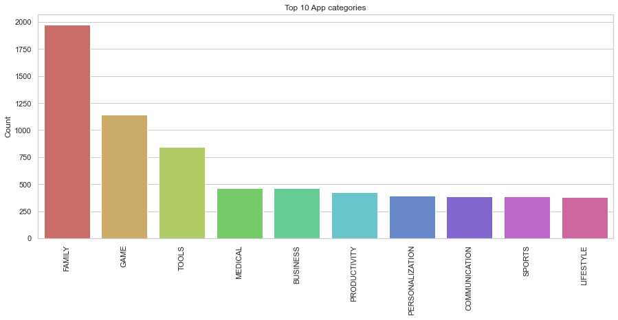

```python
plt.figure(figsize=(15,6))
sns.barplot(x=category.index[:10], y ='Count',data = category[:10],palette='hls')
plt.title('Top 10 App categories')
plt.xticks(rotation=90)
plt.show()
```

### Finding

```
1) 가장 많은 카테고리 : Family(18%), Game(11%)
2) 가장 적은 카테고리 : Beauty(1%), Cosmic(1%)
```

### 2. Rating

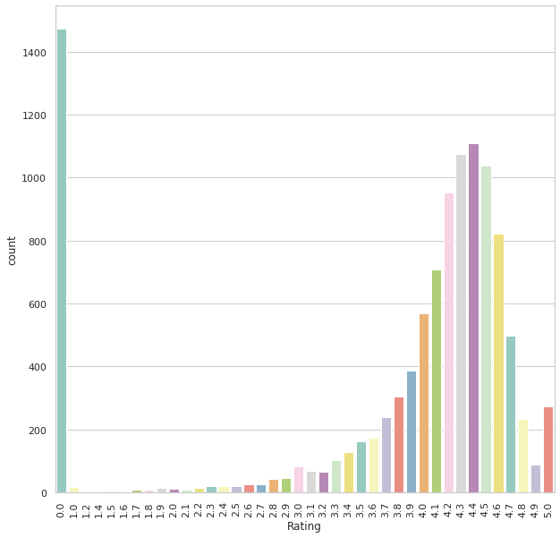

```python
#각 Rating별 갯수
plt.subplots(figsize=(10,10))
plt.xticks(rotation=90)
ax = sns.countplot(x="Rating", data=df, palette="Set3")
```

### Finding

```
1) 4점 이상의 앱 비중 : 67.97%
```

### 4.Reviews

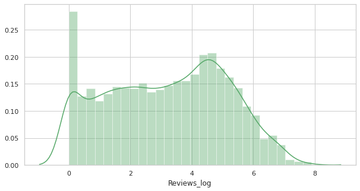

```python
#histogram

plt.figure(figsize=(10,5))
sns.distplot(df['Reviews_log'],color='g')
```

### Findings

[output not shown]

### 4. Installs

```
count    10839.000000
mean         4.809655
std          2.113071
min          0.000000
25%          3.000000
50%          5.000000
75%          6.698970
max          9.000000
Name: Installs_log, dtype: float64
```

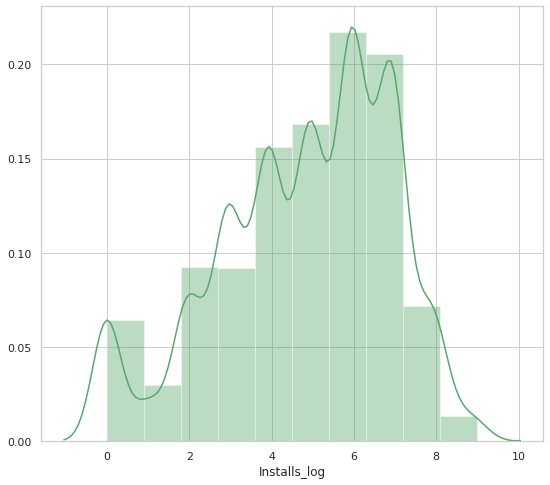

```python
print(df['Installs_log'].describe())
plt.figure(figsize=(9, 8))
sns.distplot(df['Installs_log'], color='g', bins=10, hist_kws={'alpha': 0.4});
```

### Finding

```
    1) 설치횟수가 1백만 이상인 앱의 비중 : 14.57%, 1천만 이상인 앱의 비중 : 11.55%
    2) 평균 설치 횟수 : 1천 5백만 회
    3) 최대 설치 횟수 : 10억 회
    4) 최소 설치 횟수 : 0회
```

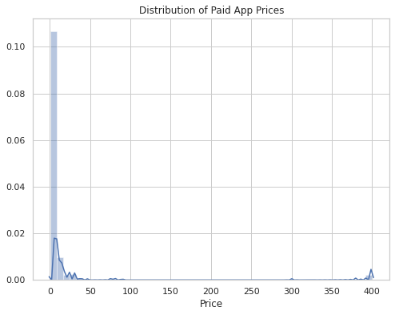

```python
plt.figure(figsize=(8,6))
plt.title('Distribution of Paid App Prices')
sns.distplot(paid_apps['Price'],bins=50)
plt.show()
```

```python
paid_apps[paid_apps['Price'] >= 350]
```

|  | App | Category | Rating | Reviews | Size | Installs | Type | Price | Content Rating | Genres | Last Updated | Current Ver | Android Ver | Reviews_log | Installs_log |
| --- | --- | --- | --- | --- | --- | --- | --- | --- | --- | --- | --- | --- | --- | --- | --- |
| 4197 | most expensive app (H) | FAMILY | 4.3 | 6 | 1.5M | 100 | Paid | 399.99 | Everyone | Entertainment | July 16, 2018 | 1.0 | 7.0 and up | 0.778151 | 2.00000 |
| 4362 | 💎 I'm rich | LIFESTYLE | 3.8 | 718 | 26M | 10000 | Paid | 399.99 | Everyone | Lifestyle | March 11, 2018 | 1.0.0 | 4.4 and up | 2.856124 | 4.00000 |
| 4367 | I'm Rich - Trump Edition | LIFESTYLE | 3.6 | 275 | 7.3M | 10000 | Paid | 400.00 | Everyone | Lifestyle | May 3, 2018 | 1.0.1 | 4.1 and up | 2.439333 | 4.00000 |
| 5351 | I am rich | LIFESTYLE | 3.8 | 3547 | 1.8M | 100000 | Paid | 399.99 | Everyone | Lifestyle | January 12, 2018 | 2.0 | 4.0.3 and up | 3.549861 | 5.00000 |
| 5354 | I am Rich Plus | FAMILY | 4.0 | 856 | 8.7M | 10000 | Paid | 399.99 | Everyone | Entertainment | May 19, 2018 | 3.0 | 4.4 and up | 2.932474 | 4.00000 |
| 5356 | I Am Rich Premium | FINANCE | 4.1 | 1867 | 4.7M | 50000 | Paid | 399.99 | Everyone | Finance | November 12, 2017 | 1.6 | 4.0 and up | 3.271144 | 4.69897 |
| 5357 | I am extremely Rich | LIFESTYLE | 2.9 | 41 | 2.9M | 1000 | Paid | 379.99 | Everyone | Lifestyle | July 1, 2018 | 1.0 | 4.0 and up | 1.612784 | 3.00000 |
| 5358 | I am Rich! | FINANCE | 3.8 | 93 | 22M | 1000 | Paid | 399.99 | Everyone | Finance | December 11, 2017 | 1.0 | 4.1 and up | 1.968483 | 3.00000 |
| 5359 | I am rich(premium) | FINANCE | 3.5 | 472 | 965k | 5000 | Paid | 399.99 | Everyone | Finance | May 1, 2017 | 3.4 | 4.4 and up | 2.673942 | 3.69897 |
| 5362 | I Am Rich Pro | FAMILY | 4.4 | 201 | 2.7M | 5000 | Paid | 399.99 | Everyone | Entertainment | May 30, 2017 | 1.54 | 1.6 and up | 2.303196 | 3.69897 |
| 5364 | I am rich (Most expensive app) | FINANCE | 4.1 | 129 | 2.7M | 1000 | Paid | 399.99 | Teen | Finance | December 6, 2017 | 2 | 4.0.3 and up | 2.110590 | 3.00000 |
| 5366 | I Am Rich | FAMILY | 3.6 | 217 | 4.9M | 10000 | Paid | 389.99 | Everyone | Entertainment | June 22, 2018 | 1.5 | 4.2 and up | 2.336460 | 4.00000 |
| 5369 | I am Rich | FINANCE | 4.3 | 180 | 3.8M | 5000 | Paid | 399.99 | Everyone | Finance | March 22, 2018 | 1.0 | 4.2 and up | 2.255273 | 3.69897 |
| 5373 | I AM RICH PRO PLUS | FINANCE | 4.0 | 36 | 41M | 1000 | Paid | 399.99 | Everyone | Finance | June 25, 2018 | 1.0.2 | 4.1 and up | 1.556303 | 3.00000 |

### Finding

[output not shown]

# 컬럼 별 상관관계 분석

```
1) Reviews_log - Installs_log
2) Reviews_log - Rating
```

```python
df.corr()['Reviews_log']
```

```
Rating          0.595889
Reviews         0.289233
Installs        0.314721
Price          -0.028740
Reviews_log     1.000000
Installs_log    0.956194
Name: Reviews_log, dtype: float64
```

## 1. Reviews_log와 Installs_log 분석

```
1) log값 취한 데이터를 기준으로 상관성 분석
2) 목표하는 Installs 컬럼을 포함한 전체 특징들과 분석
```

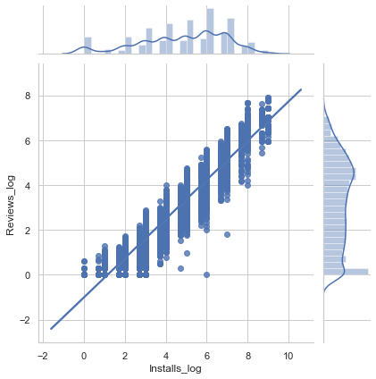

```python
# joint scatter plot

sns.jointplot(x="Installs_log", y="Reviews_log", data=df, kind='reg')
```

```python
df.corr()['Reviews_log']
```

[output not shown]

### Finding

```
Reviews수의 로그를 취한 데이터와 상관관계를 보인 데이터
    : Installs_log, Rating
```

## 2. Rating, Reviews_log 선형 분석

```
1) log값 취한 데이터를 기준으로 상관성 분석
2) Reviews와의 상관관계를 보이는 feature에 대한 추가 탐색
```

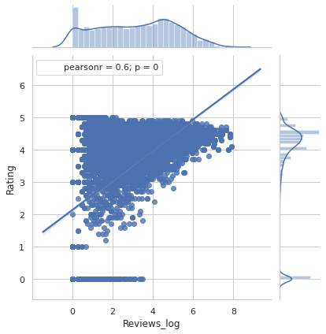

```python
j = sns.jointplot(x="Reviews_log", y="Rating", data=df, kind='reg')
j.annotate(stats.pearsonr)
plt.show()
```

# Reviews 데이터 분석

```
1) Reviews가 높은 Install과 Rating의 유의미한 상관관계를 보이는 feature임을 확인
2) 이에 따라, 별도의 Review의 User_data 활용 분석
3) 상위 Install 앱의 Reivew 데이터 분석 실시
```

### Installs_log, Reviews_log의 sorting 결과, 상위 10개 데이터 분석

```python
df1 = df1.sort_values(by=['Installs_log', 'Reviews_log'], ascending=False)
df1.head(10)
```

|  | Category | Rating | reviews | Installs | Reviews_log | Installs_log |
| --- | --- | --- | --- | --- | --- | --- |
| 2544 | SOCIAL | 4.1 | 78158306.0 | 1.000000e+09 | 7.892975 | 9.0 |
| 3943 | SOCIAL | 4.1 | 78128208.0 | 1.000000e+09 | 7.892808 | 9.0 |
| 336 | COMMUNICATION | 4.4 | 69119316.0 | 1.000000e+09 | 7.839599 | 9.0 |
| 381 | COMMUNICATION | 4.4 | 69119316.0 | 1.000000e+09 | 7.839599 | 9.0 |
| 3904 | COMMUNICATION | 4.4 | 69109672.0 | 1.000000e+09 | 7.839539 | 9.0 |
| 2604 | SOCIAL | 4.5 | 66577446.0 | 1.000000e+09 | 7.823327 | 9.0 |
| 2545 | SOCIAL | 4.5 | 66577313.0 | 1.000000e+09 | 7.823326 | 9.0 |
| 2611 | SOCIAL | 4.5 | 66577313.0 | 1.000000e+09 | 7.823326 | 9.0 |
| 3909 | SOCIAL | 4.5 | 66509917.0 | 1.000000e+09 | 7.822886 | 9.0 |
| 382 | COMMUNICATION | 4.0 | 56646578.0 | 1.000000e+09 | 7.753174 | 9.0 |

### Installs, Reviews 상위 10개 App

```python
df_or.iloc[[2544, 3943, 336, 381, 3904, 2604, 2545, 2611, 3909, 382]].App
```

```
2544                                    Facebook
3943                                    Facebook
336                           WhatsApp Messenger
381                           WhatsApp Messenger
3904                          WhatsApp Messenger
2604                                   Instagram
2545                                   Instagram
2611                                   Instagram
3909                                   Instagram
382     Messenger – Text and Video Chat for Free
Name: App, dtype: object
```

### Install, Review 최다횟수 보유 app인 Facebook의 Review Data 분석

```
- Sentiment 위주 분석 진행
```

```python
df_facebook = df_r.loc[df_r["App"] == 'Facebook']
df_facebook_f = df_facebook.sort_values(by='Sentiment_Polarity', ascending=False)
df_facebook_f.head(10)
```

|  | App | Translated_Review | Sentiment | Sentiment_Polarity | Sentiment_Subjectivity |
| --- | --- | --- | --- | --- | --- |
| 42887 | Facebook | The best free | Positive | 0.700000 | 0.550000 |
| 42904 | Facebook | Good | Positive | 0.700000 | 0.600000 |
| 42891 | Facebook | Beautiful and sweet. * | Positive | 0.600000 | 0.825000 |
| 42871 | Facebook | Do understand hindi? If understand problem mem... | Positive | 0.500000 | 0.625000 |
| 42848 | Facebook | I updated Facebook still way find marketplace.... | Positive | 0.500000 | 0.500000 |
| 42971 | Facebook | Some error keeps popping everytime I link sayi... | Positive | 0.472222 | 0.700000 |
| 42940 | Facebook | Ok I'm kinda fed Facebook right now.... I clue... | Positive | 0.428571 | 0.553571 |
| 42961 | Facebook | Would great change constantly. The videos inco... | Positive | 0.383333 | 0.544444 |
| 42967 | Facebook | Hi Facebook, far awesome. Just hope Facebook p... | Positive | 0.366667 | 1.000000 |
| 42844 | Facebook | Like wont let post pics groups select pic gall... | Positive | 0.350000 | 0.450000 |

### Facebook의 Review의 Sentiment 분포도

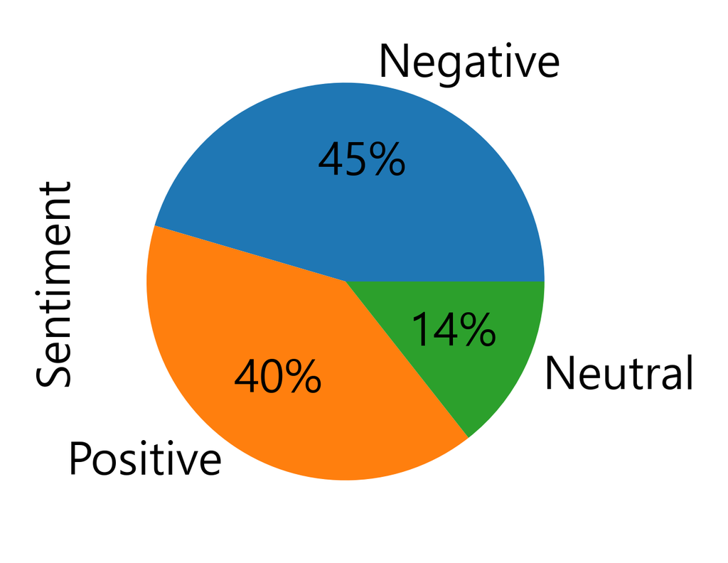

```python
df_facebook["Sentiment"].value_counts().plot.pie(label='Sentiment', autopct='%1.0f%%', figsize=(2, 2))
```

### Whats_app, Instagram 대한 Review들은 data가 존재하지 않아 분석할 수 없음

```
- 이유 : 데이터 부재(App 이름의 'I' 이후 데이터 부재)
```

# Conclusion

[output not shown]